# IPCA

03/12/2022

## IPCA nos últimos 12 meses

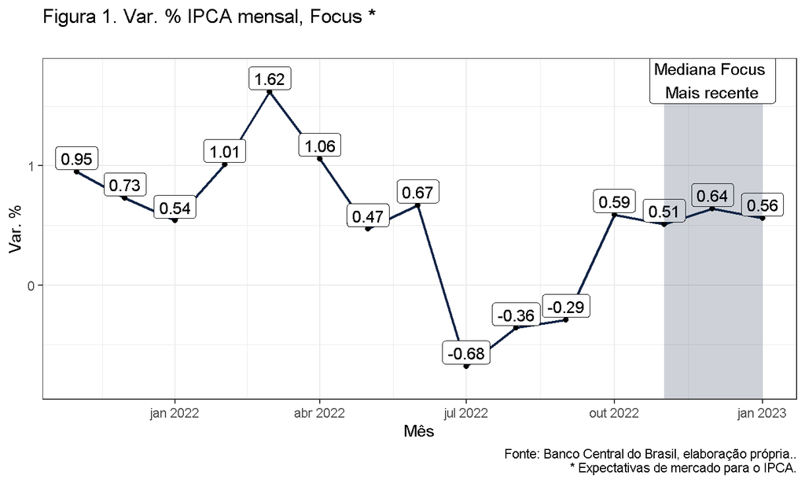

## Acumulado em 12 meses

Em 12 meses o IPCA acumula uma variação de **6.47 %**.

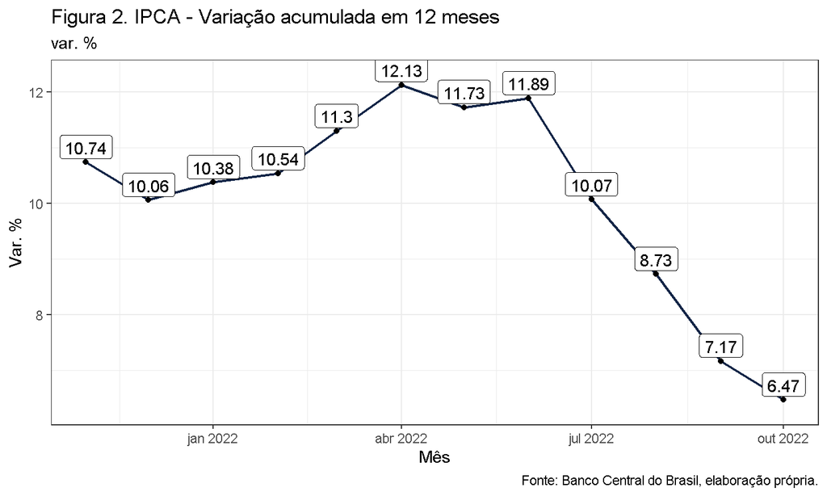

## IPCA no último mês por Grupo

Dentre os grupos que compõe IPCA o que apresentou maior crescimento foi o de **Vestuário** Com o percentual de **1.22 %** e o que apresentou menor crescimento foi o grupo **Comunicação** Com o percentual de **-0.48 %**

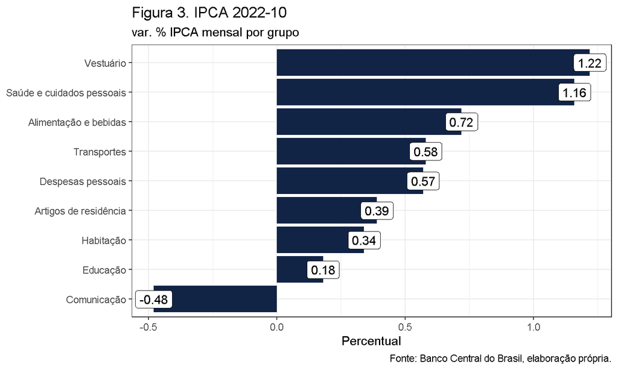

## IPCA no último mês por Subitem

Dos subitens que compõem o IPCA os três que mais contribuiram para o índice foram  
**Passagem aérea**, **Perfume** e **Plano de saúde** que juntos contribuiram com **0.274** pontos percentuais de um total de **0.59**.

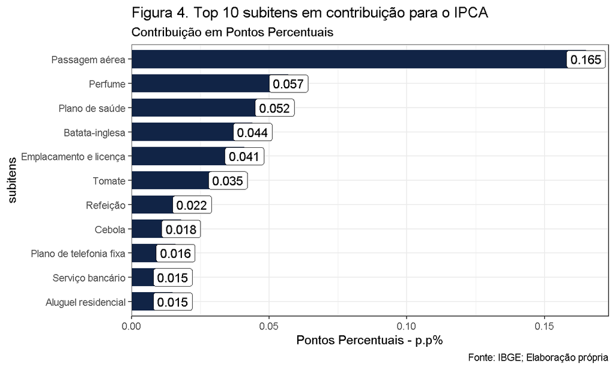

## Maiores Variações no mês

Dos subitens que compõem o IPCA os três com maior variação no mês foram  
**Pepino**, **Passagem aérea** e **Batata-inglesa** com variação de **27.54 %**, **27.38 %** e **23.36 %** respectivamente.

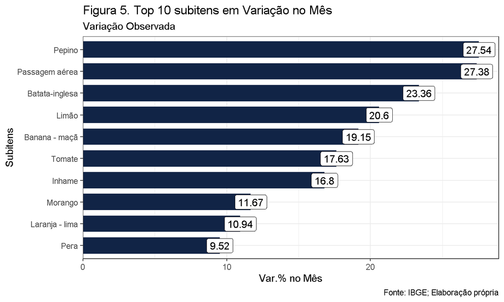

## Dez Maiores Reduções no Mês

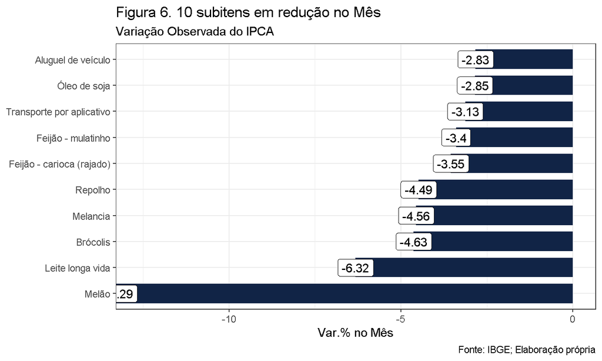

## Dez maiores Variações no grupo de Alimentação e bebidas

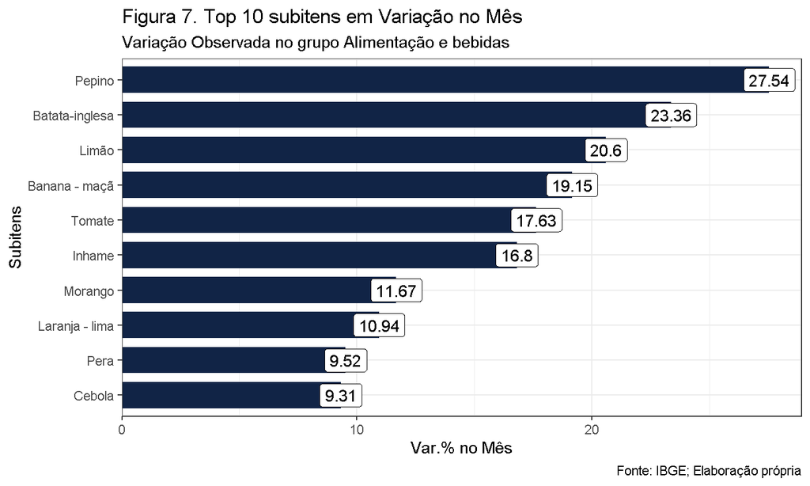

## Dez maiores Variações no grupo de Habitação

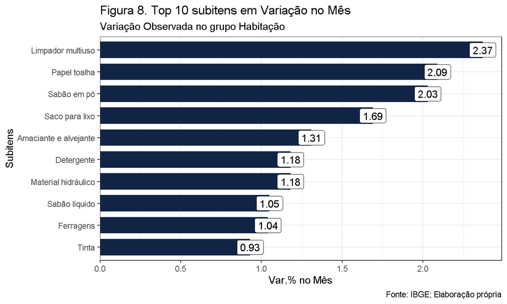

## Dez maiores Variações no grupo de Transportes

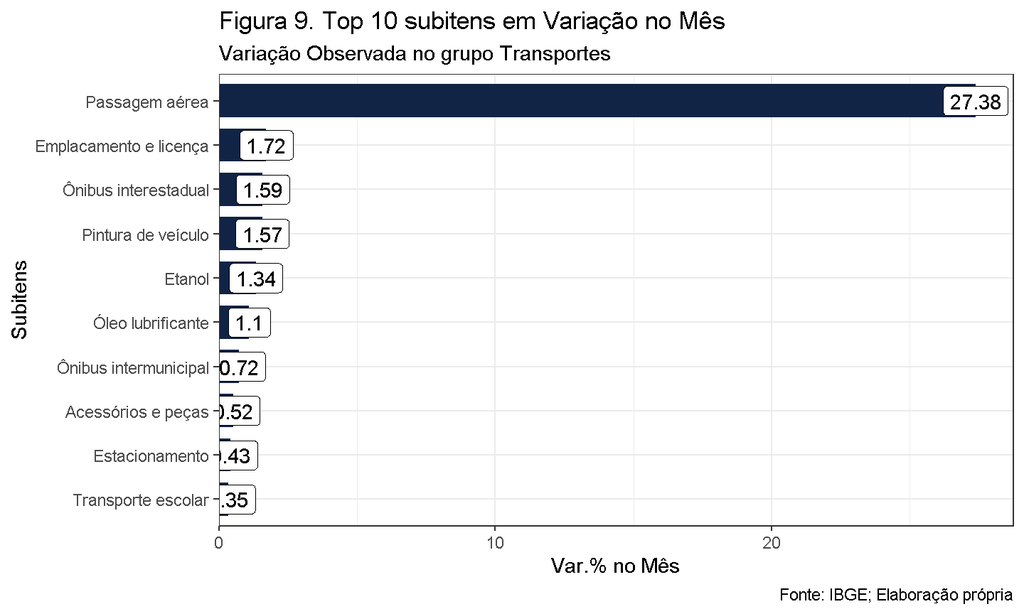

## Dez maiores Variações no grupo de Despesas pessoais

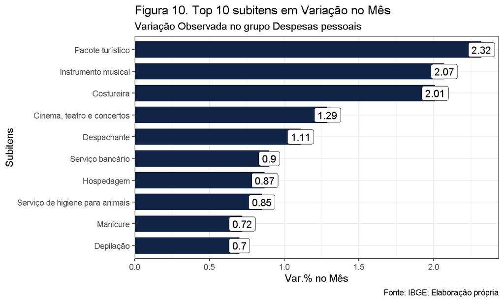

## Dez maiores Variações no grupo de Vestuário

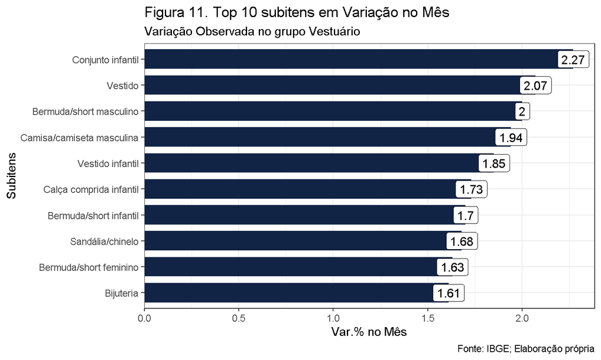

## Dez maiores Variações no grupo de Saúde e cuidados pessoais

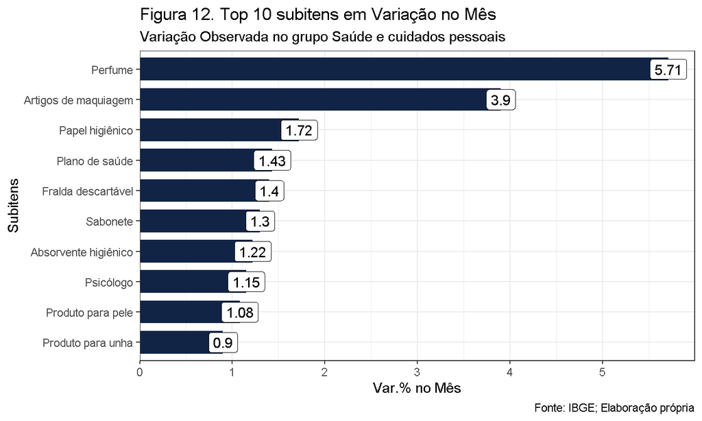

## Dez maiores Variações no grupo de Artigos de residência

[figure not shown]

## Dez maiores Variações no grupo de Comunicação

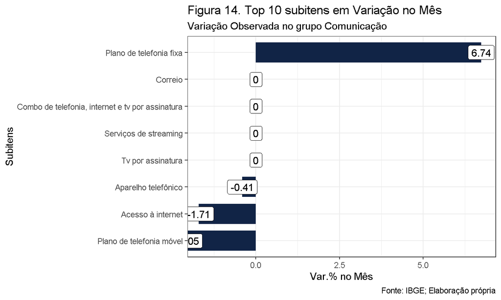

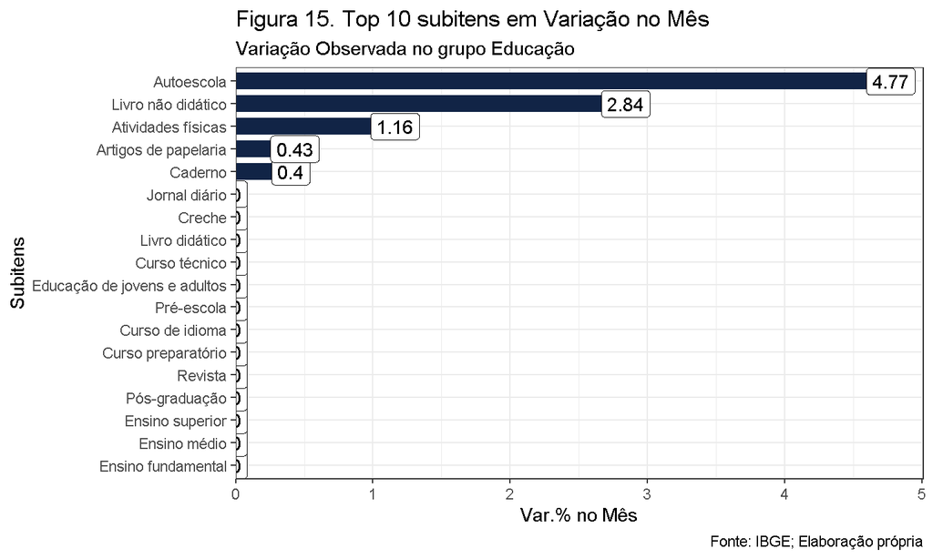

## Maiores Variações no ano

Dos subitens que compõem o IPCA os três com maior variação acumulada no ano corrente foram **Cebola**, **Limão** e **Melão** com variação de **78.92 %**, **68.85 %** e **51.21 %** respectivamente.

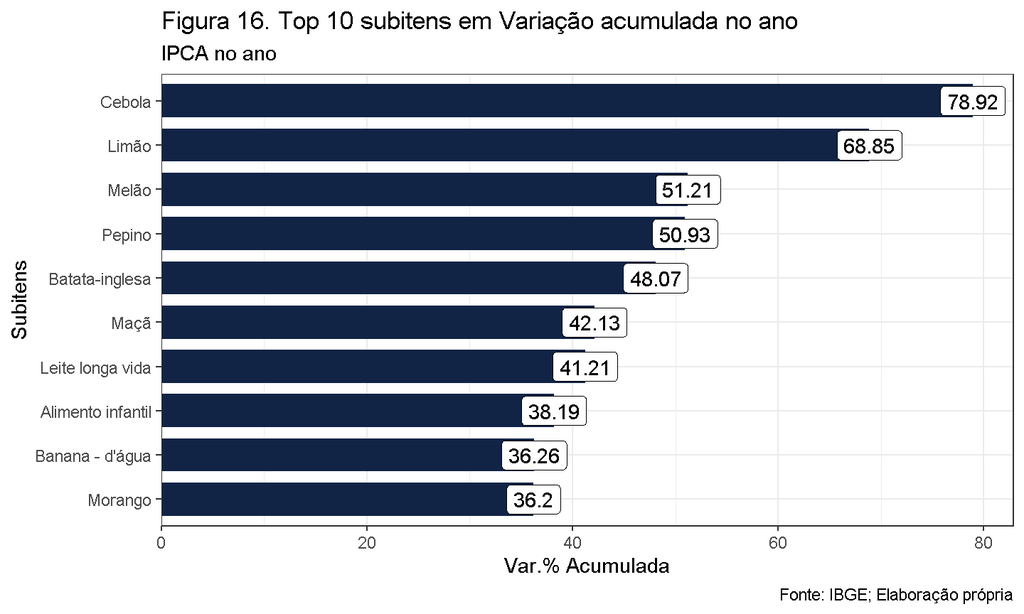

## Maiores Variações em 12 meses

Dos subitens que compõem o IPCA os três com maior variação acumulada em 12 meses foram  
**Cebola**, **Limão** e **Mamão** com variação de **151.76 %**, **92.04 %** e **64.06 %** respectivamente.

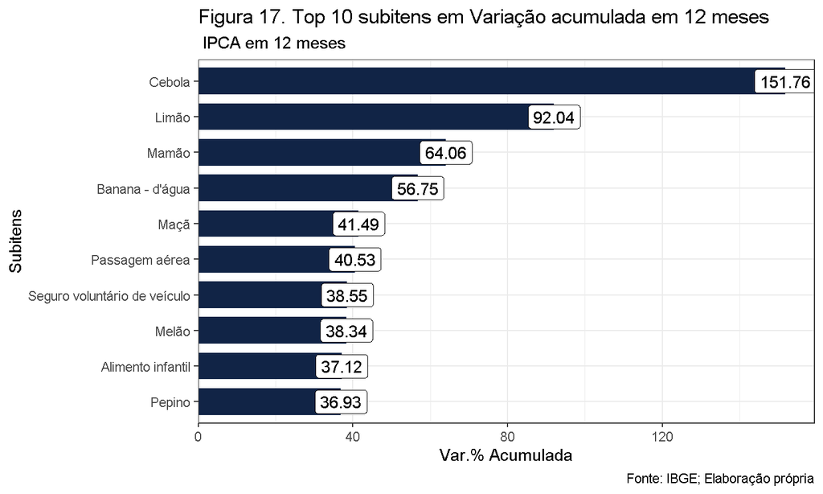